# Оформление отчетов в Markdown

Отчет по лабораторной работе №3

Садыков Ильдар Ильфатович

sad.ildar0406@gmail.com

Российский университет дружбы народов

2026-03-03

# Вводная часть

## Актуальность

- Markdown — удобный язык разметки для оформления документации
- Quarto позволяет конвертировать Markdown в различные форматы
- Автоматизация создания отчетов экономит время
- Единый исходный код для разных целевых форматов

## Объект и предмет исследования

- Объект исследования: процесс оформления отчетов
- Предмет исследования: язык разметки Markdown и система Quarto

## Цели и задачи

**Цель:** Научиться оформлять отчеты с помощью языка разметки Markdown.

**Задачи:**

1. Создать отчет по предыдущей лабораторной работе в формате Markdown
2. Скомпилировать отчет в различные форматы с помощью Quarto
3. Получить файлы отчета в форматах PDF и DOCX
4. Получить файлы презентации в форматах PDF и HTML

## Материалы и методы

- **Оборудование:** ПК с ОС Linux (Fedora Sway)
- **ПО:** Quarto, Pandoc, LaTeX
- **Методы:** Написание в Markdown, компиляция через Makefile

# Выполнение лабораторной работы

## Создание отчета

- Открыт файл отчета в соответствующем каталоге
- Отредактировано содержание в формате Markdown

## Компиляция через Quarto

- Использована команда `make` для компиляции
- Получены готовые файлы в различных форматах

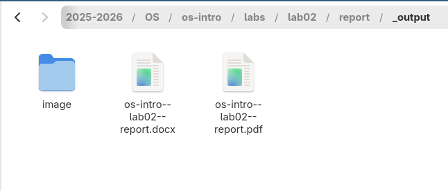

Рисунок 1: Полученные файлы отчета

## Результаты компиляции

**Для отчета:** - PDF - DOCX

**Для презентации:** - PDF - HTML

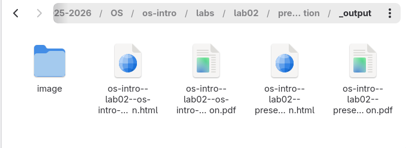

Рисунок 2: Полученные файлы презентации

# Выводы

## Выводы

- В ходе работы освоены навыки оформления отчетов с помощью Markdown
- Освоена конвертация отчетов в различные форматы через Quarto
- Получены файлы отчетов и презентаций в требуемых форматах
- Автоматизирован процесс создания документации